# Pract Machine Learning - Project Write_Up

Chi Ngo

Tuesday, March 17, 2015

# Summary

This is intended to recognize the quality of weight lifting exercises based on data provided by 4 sensors located on belt, arm, forearm and the dumbbell.

```r
## Loading Data
library(caret)
library(rpart)
training <- read.csv("pml-training.csv")
testing <- read.csv("pml-testing.csv")
ds <- training[, c(2, 6:10, 37:45, 46:49, 60:68, 84:86, 102, 113:121, 122:124, 140, 151:160)]
ds2 <- training[, c(8:10, 37:45, 46:49, 60:68, 84:86, 102, 113:121, 122:124, 140, 151:160)]
```

# Machine Learning Algorithm

The Regression Tree rpart is used in this classification problem. The training dataset is simplified by keeping just 56 variables among the 160 variables of the original training dataset. This also eliminates all the NAs in the dataset. The list of 56 variables includes: - “classe”: response - “user name”: not considered - “new_window” - “num_window” - 52 features resulting from the sensors used for recognition the quality of actions during the exercises, namely: - good: “A” - bad: “B”, “C”, “D” and “E”

- Data sets: Training dataset and Testing dataset
- Testing data set does not include the responses

### The “train” function of “caret” is used with rpart as a method with 10-fold cross validation.

### Resampling will be repeated three times

### Apply the classification model to the testing dataset. The accuracy achieved is 80%.

```r
set.seed(4699)
cvCtrl <- trainControl(method="repeatedcv", repeats=3)
fit <- train(classe ~ ., data=ds2, method="rpart", tuneLength=30, trControl=cvCtrl)
pred <- predict(fit, newdata=testing)
```

### Special information: Window number

#### For every window number, there is corresponding to only one response although there are several observations.

#### Testing data set does not contain the response but it contains the window number that permits to get the corresponding outcome

```r
outcome <- vector()
for (j in 1:nrow(testing)) {
  sub <- subset(ds, num_window==testing[j,]$num_window, select=classe)
  outcome[j] <- as.character(sub[1,])
}
outcome <- factor(outcome)
```

### Comparison of real outcome against Predicted - ConfusionMatrix

```r
results <- rbind(as.character(outcome), as.character(pred))
rownames(results) <- c("Outcomes", "Predicted")
results
```

```
##           [,1] [,2] [,3] [,4] [,5] [,6] [,7] [,8] [,9] [,10] [,11] [,12]
## Outcomes  "B"  "A"  "B"  "A"  "A"  "E"  "D"  "B"  "A"  "A"   "B"   "C"
## Predicted "B"  "A"  "B"  "A"  "A"  "C"  "D"  "A"  "A"  "A"   "C"   "B"
##           [,13] [,14] [,15] [,16] [,17] [,18] [,19] [,20]
## Outcomes  "B"   "A"   "E"   "E"   "A"   "B"   "B"   "B"
## Predicted "B"   "A"   "E"   "E"   "A"   "B"   "B"   "B"
```

```r
# Confusion Matrix
confusionMatrix(pred, outcome)
```

```
## Confusion Matrix and Statistics
##
##           Reference
## Prediction A B C D E
##          A 7 1 0 0 0
##          B 0 6 1 0 0
##          C 0 1 0 0 1
##          D 0 0 0 1 0
##          E 0 0 0 0 2
##
## Overall Statistics
##
##                Accuracy : 0.8
##                  95% CI : (0.5634, 0.9427)
##     No Information Rate : 0.4
##     P-Value [Acc > NIR] : 0.000317
##
##                   Kappa : 0.7133
##  Mcnemar's Test P-Value : NA
##
## Statistics by Class:
##
##                      Class: A Class: B Class: C Class: D Class: E
## Sensitivity            1.0000   0.7500   0.0000     1.00   0.6667
## Specificity            0.9231   0.9167   0.8947     1.00   1.0000
## Pos Pred Value         0.8750   0.8571   0.0000     1.00   1.0000
## Neg Pred Value         1.0000   0.8462   0.9444     1.00   0.9444
## Prevalence             0.3500   0.4000   0.0500     0.05   0.1500
## Detection Rate         0.3500   0.3000   0.0000     0.05   0.1000
## Detection Prevalence   0.4000   0.3500   0.1000     0.05   0.1000
## Balanced Accuracy      0.9615   0.8333   0.4474     1.00   0.8333
```

```r
paste("Accuracy: 80%")
```

```
## [1] "Accuracy: 80%"
```

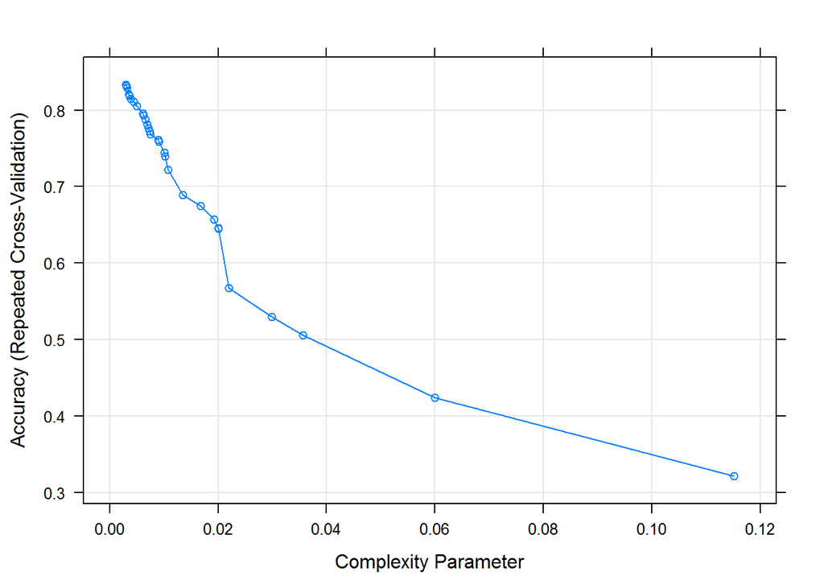

```r
plot.train(fit)
```

Root node error: 14042/19622 = 0.71563

n= 19622

## Pruning to avoid overfitting

## However, after pruning, the accuracy is just 45%

```r
par(xpd = TRUE)
fp <-prune(fit$finalModel, cp=0.0168)
prunedPred <- predict(fp, newdata=testing)
predpr <- array()
for (i in 1:nrow(prunedPred)) {
  predpr[i]<- names(which(prunedPred[i,]==max(prunedPred[i,])))
}
predpr <- factor(predpr)
confusionMatrix(predpr, outcome)
```

```
## Confusion Matrix and Statistics
##
##           Reference
## Prediction A B C D E
##          A 5 2 0 0 0
##          B 0 2 1 0 0
##          C 0 3 0 0 1
##          D 2 1 0 1 1
##          E 0 0 0 0 1
##
## Overall Statistics
##
##                Accuracy : 0.45
##                  95% CI : (0.2306, 0.6847)
##     No Information Rate : 0.4
##     P-Value [Acc > NIR] : 0.4044
##
##                   Kappa : 0.3016
##  Mcnemar's Test P-Value : NA
##
## Statistics by Class:
##
##                      Class: A Class: B Class: C Class: D Class: E
## Sensitivity            0.7143   0.2500   0.0000   1.0000   0.3333
## Specificity            0.8462   0.9167   0.7895   0.7895   1.0000
## Pos Pred Value         0.7143   0.6667   0.0000   0.2000   1.0000
## Neg Pred Value         0.8462   0.6471   0.9375   1.0000   0.8947
## Prevalence             0.3500   0.4000   0.0500   0.0500   0.1500
## Detection Rate         0.2500   0.1000   0.0000   0.0500   0.0500
## Detection Prevalence   0.3500   0.1500   0.2000   0.2500   0.0500
## Balanced Accuracy      0.7802   0.5833   0.3947   0.8947   0.6667
```

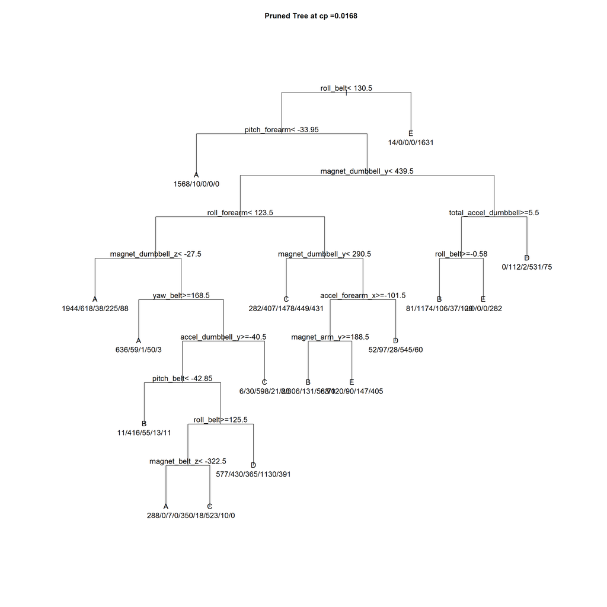

```r
plot(fp, compress = TRUE, uniform=T, margin=.1, main="Pruned Tree at cp =0.0168",
     lwd = 12)
text(fp, use.n = TRUE, cex = 1.2)
```